# Fundamentals of computing and data display

2 04 2020

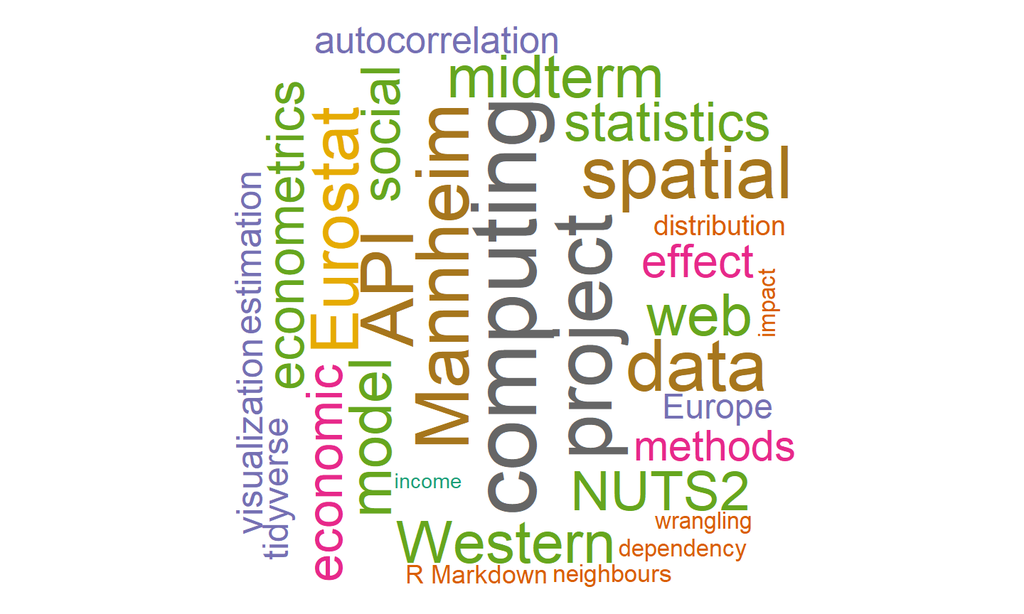

## Motivation

Regional variability of median household income in Western Europe exceeded 15% in 2017 for NUTS 2 level and was probably way higher for lower level analysis f.e. NUTS 3.

That fact raises some important questions as:

- Why are households in some regions much richer than in others?
- What can resonable decision makers do to make particular regions prosper better?
- Are there any connections between regions in that matter?

In this paper we will try to adress those question using web data and some statistical tools.

## Household income determinants in Western Europe - NUTS 2 level

- Which factors drive median household income the most?
- What are the signs of coefficients and are they in-line with the theory?
- Is there some kind of spatial dependency and if so how can we explain it?
- Assuming there is a huge investment in Brandenburg region resulting in a certain decrease of unemployment rate are we able to predict the extend of impact on household income for the neighbouring regions?

## Data collection (1/2)

To conduct the analysis we need some data on socio-economic variables for the statistical unitis in Europe. The most recent and reliable data in that matter is provided by **Eurostat** so we are going to use its API…

[figure not shown]

## Data collection (2/2)

… with R package **eurostat**!

```r
library(eurostat)
library(tidyverse)

search_eurostat("NUTS 2") %>%
  filter(`data end` >= 2017) %>%
  arrange(desc(`last update of data`))%>%
  select(title)%>%
  head(3)
```

```
## # A tibble: 3 x 1
##   title
##   <chr>
## 1 Hospital beds by NUTS 2 regions
## 2 Long-term unemployment (12 months and more) by NUTS 2 regions
## 3 Hospital beds by NUTS 2 regions
```

## Funcionality overview (1/2)

```r
library(eurostat)

get_eurostat("nama_10r_2hhinc") %>%
  subset(grepl("(DE|AT|FR|NL|BE)([0-9]|[A-Z]){2}", geo)) %>%
  filter(time == "2017-01-01", unit == "PPS_HAB", na_item == "B6N")%>%
  head(7)
```

```
## # A tibble: 7 x 6
##   unit    direct na_item geo   time       values
##   <fct>   <fct>  <fct>   <fct> <date>      <dbl>
## 1 PPS_HAB BAL    B6N     AT11  2017-01-01  22300
## 2 PPS_HAB BAL    B6N     AT12  2017-01-01  22600
## 3 PPS_HAB BAL    B6N     AT13  2017-01-01  20700
## 4 PPS_HAB BAL    B6N     AT21  2017-01-01  21300
## 5 PPS_HAB BAL    B6N     AT22  2017-01-01  21500
## 6 PPS_HAB BAL    B6N     AT31  2017-01-01  21900
## 7 PPS_HAB BAL    B6N     AT32  2017-01-01  22400
```

## Funcionality overview (2/2)

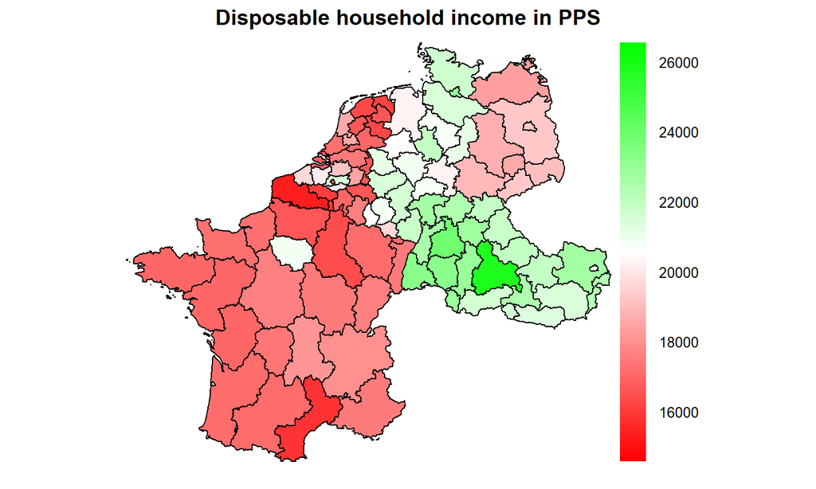

## Methods

The analysis will be conducted with tools of spatial econometrics, i.e.

1. We regress households income on several socio-economic variables.
2. Then we look for patterns in the spatial distribution of residuals.
3. If spatial dependency is present (spoiler alert: **it is!**) we are going to propose some models of single-source as well as dual-source spatial processes.
4. Then we choose the best one and confront it with the theory.
5. In the end we will conduct a simulation to see how the system reacts for a given impuls.

## Sneak peek (1/2)

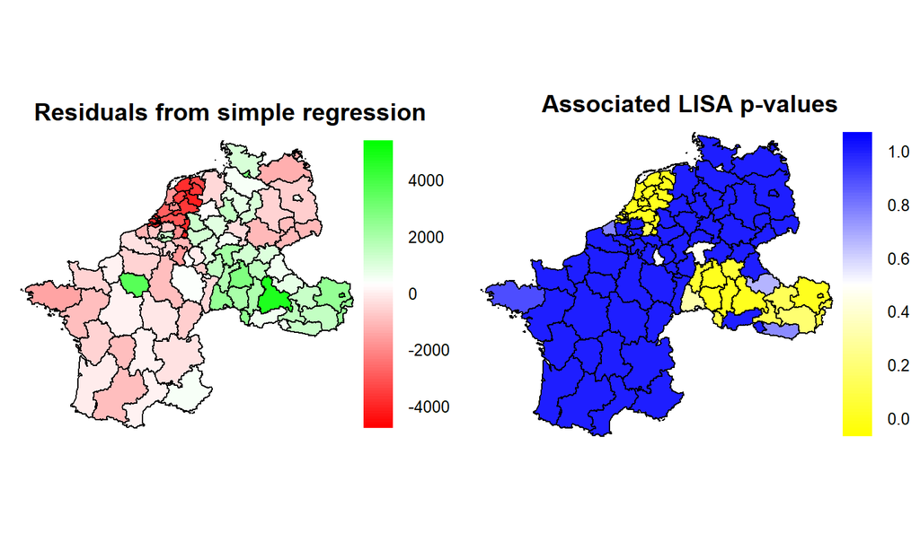

## Sneak peek (2/2)

[figure not shown]

### Danke für Ihre Aufmerksamkeit!